# Google Data Analytics Capstone Project

Saad Ahmed Qureshi

2022-09-03

## Objectives of analysis

1. How do annual members and casual riders use Cyclistic bikes differently?
2. Why would casual riders buy Cyclistic annual memberships?
3. How can Cyclistic use digital media to influence casual riders to become members?

Business Task: How can the annual members be increased. What marketing strategy should be device to convert casual bike riders to annual members.

## Data Preparation:

Link of the data is provided with the case stude and present on AWS server. I have downloaded previous 12 months data from “2021-08” to “2022-07” for my project. Data is present in quarterly and monthly format. I have used 12 months files and merge it to complete data. Since the data was provided by the Cyclistic company itself therefore we can consider it as reliable. Data is Reliable, Original, Comprehensive, Current and cited (ROCCC).

### Setting working directory (where data is stored)

```r
setwd("H:/Others/Google Capstone Project/Data/Combined Data")
```

### All files have same data structure,; column names and valeus are unique

```r
files <- list.files(pattern = ".csv")
temp <- lapply(files, fread, sep=",", encoding = "UTF-8")
dt <- rbindlist(temp)
```

### Viewing data type of data

```r
str(dt)
```

```
## Classes 'data.table' and 'data.frame':   11802926 obs. of  14 variables:
##  $ V1                : int  1 2 3 4 5 6 7 8 9 10 ...
##  $ ride_id           : chr  "99103BB87CC6C1BB" "EAFCCCFB0A3FC5A1" "9EF4F46C57AD234D" "5834D3208BFAF1DA" ...
##  $ rideable_type     : chr  "electric_bike" "electric_bike" "electric_bike" "electric_bike" ...
##  $ started_at        : POSIXct, format: "2021-08-10 17:15:49" "2021-08-10 17:23:14" ...
##  $ ended_at          : POSIXct, format: "2021-08-10 17:22:44" "2021-08-10 17:39:24" ...
##  $ start_station_name: chr  "" "" "" "" ...
##  $ start_station_id  : chr  "" "" "" "" ...
##  $ end_station_name  : chr  "" "" "" "" ...
##  $ end_station_id    : chr  "" "" "" "" ...
##  $ start_lat         : num  41.8 41.8 42 42 41.8 ...
##  $ start_lng         : num  -87.7 -87.7 -87.7 -87.7 -87.6 ...
##  $ end_lat           : num  41.8 41.8 42 42 41.8 ...
##  $ end_lng           : num  -87.7 -87.6 -87.7 -87.7 -87.6 ...
##  $ member_casual     : chr  "member" "member" "member" "member" ...
##  - attr(*, ".internal.selfref")=<externalptr>
```

```r
nrow(dt)
```

```
## [1] 11802926
```

```r
dim(dt)
```

```
## [1] 11802926       14
```

```r
head(dt)
```

```
##    V1          ride_id rideable_type          started_at            ended_at
## 1:  1 99103BB87CC6C1BB electric_bike 2021-08-10 17:15:49 2021-08-10 17:22:44
## 2:  2 EAFCCCFB0A3FC5A1 electric_bike 2021-08-10 17:23:14 2021-08-10 17:39:24
## 3:  3 9EF4F46C57AD234D electric_bike 2021-08-21 02:34:23 2021-08-21 02:50:36
## 4:  4 5834D3208BFAF1DA electric_bike 2021-08-21 06:52:55 2021-08-21 07:08:13
## 5:  5 CD825CB87ED1D096 electric_bike 2021-08-19 11:55:29 2021-08-19 12:04:11
## 6:  6 612F12C94A964F3E electric_bike 2021-08-19 12:41:12 2021-08-19 12:47:47
##    start_station_name start_station_id end_station_name end_station_id
## 1:
## 2:
## 3:
## 4:
## 5:
## 6:
##    start_lat start_lng end_lat end_lng member_casual
## 1:     41.77    -87.68   41.77  -87.68        member
## 2:     41.77    -87.68   41.77  -87.63        member
## 3:     41.95    -87.65   41.97  -87.66        member
## 4:     41.97    -87.67   41.95  -87.65        member
## 5:     41.79    -87.60   41.77  -87.62        member
## 6:     41.81    -87.61   41.80  -87.60        member
```

### “dt” Data Frame contains original data

## Data Cleaning Steps

### Removing all rows where there is a blank in data, Only considering “Complete Ride” for analysis

### Removing all blank rows where data type is numeric and developing new data frame

```r
df <- dt[complete.cases(dt),]
```

### Removing blanks from char datatype

```r
df<-df[!(df$ride_id == ""),]
df<-df[!(df$rideable_type == ""),]
df<-df[!(df$start_station_name == ""),]
df<-df[!(df$start_station_id == ""),]
df<-df[!(df$end_station_name == ""),]
df<-df[!(df$end_station_id == ""),]
```

### Now we have to decide how to proceed further. Since I have a huge data (one year data “2021-08” to “2022-07”)

### Therefore, I am removing missing rows data from my analysis and only considering rides which has all the information as “complete ride”

### Even after removing blank rows we still have big data for analysis

### Viewing individual columns to see if there is still need for data cleaning

```r
table(df$end_station_name)
```

[output not shown]

[output cut: 2614 more lines]

```
##                                                            14830
##                                           Woodlawn Ave & 75th St
##                                                              104
##                                     Woodlawn Ave & Lake Park Ave
##                                                             2802
##                                              Yale Ave & 119th St
##                                                                2
##                                             Yates Blvd & 75th St
##                                                              478
##                                             Yates Blvd & 93rd St
##                                                              150
##                                        Yates Blvd & Exchange Ave
##                                                                6
##                                                   Zapata Academy
##                                                                2
```

```r
table(is.na(df$start_lat))
```

```
##
##   FALSE
## 9258460
```

```r
any(is.na(df$rideable_type))
```

```
## [1] FALSE
```

```r
any(is.na(df$started_at))
```

```
## [1] FALSE
```

```r
any(is.na(df$ended_at))
```

```
## [1] FALSE
```

```r
any(is.na(df$start_station_name))
```

```
## [1] FALSE
```

```r
any(is.na(df$start_station_id))
```

```
## [1] FALSE
```

```r
any(is.na(df$end_station_name))
```

```
## [1] FALSE
```

```r
any(is.na(df$end_station_id))
```

```
## [1] FALSE
```

```r
any(is.na(df$start_lat))
```

```
## [1] FALSE
```

```r
any(is.na(df$start_lng))
```

```
## [1] FALSE
```

```r
any(is.na(df$end_lat))
```

```
## [1] FALSE
```

```r
any(is.na(df$end_lng))
```

```
## [1] FALSE
```

```r
any(is.na(df$member_casual))
```

```
## [1] FALSE
```

```r
sum(!complete.cases(df))
```

```
## [1] 0
```

###Viewing data type and other properties

```r
str(df)
```

```
## Classes 'data.table' and 'data.frame':   9258460 obs. of  14 variables:
##  $ V1                : int  31 37 41 73 122 124 150 152 191 203 ...
##  $ ride_id           : chr  "DD06751C6019D865" "79973DC3B232048F" "0249AD4B258806AD" "F41EB054E44ACFDA" ...
##  $ rideable_type     : chr  "classic_bike" "classic_bike" "classic_bike" "classic_bike" ...
##  $ started_at        : POSIXct, format: "2021-08-08 17:21:26" "2021-08-27 08:53:52" ...
##  $ ended_at          : POSIXct, format: "2021-08-08 17:25:37" "2021-08-27 09:18:29" ...
##  $ start_station_name: chr  "Desplaines St & Kinzie St" "Larrabee St & Armitage Ave" "Aberdeen St & Jackson Blvd" "Michigan Ave & Oak St" ...
##  $ start_station_id  : chr  "TA1306000003" "TA1309000006" "13157" "13042" ...
##  $ end_station_name  : chr  "Kingsbury St & Kinzie St" "Michigan Ave & Oak St" "Aberdeen St & Jackson Blvd" "Michigan Ave & Oak St" ...
##  $ end_station_id    : chr  "KA1503000043" "13042" "13157" "13042" ...
##  $ start_lat         : num  41.9 41.9 41.9 41.9 41.9 ...
##  $ start_lng         : num  -87.6 -87.6 -87.7 -87.6 -87.6 ...
##  $ end_lat           : num  41.9 41.9 41.9 41.9 41.9 ...
##  $ end_lng           : num  -87.6 -87.6 -87.7 -87.6 -87.6 ...
##  $ member_casual     : chr  "member" "member" "member" "casual" ...
##  - attr(*, ".internal.selfref")=<externalptr>
```

```r
nrow(df)
```

```
## [1] 9258460
```

```r
dim(df)
```

```
## [1] 9258460      14
```

```r
head(df)
```

```
##     V1          ride_id rideable_type          started_at            ended_at
## 1:  31 DD06751C6019D865  classic_bike 2021-08-08 17:21:26 2021-08-08 17:25:37
## 2:  37 79973DC3B232048F  classic_bike 2021-08-27 08:53:52 2021-08-27 09:18:29
## 3:  41 0249AD4B258806AD  classic_bike 2021-08-08 12:59:18 2021-08-08 12:59:55
## 4:  73 F41EB054E44ACFDA  classic_bike 2021-08-12 16:52:09 2021-08-12 16:56:51
## 5: 122 B149E6C71A1C3B14  classic_bike 2021-08-23 15:33:04 2021-08-23 16:09:00
## 6: 124 C41829CD6CC5A8B6  classic_bike 2021-08-23 10:11:09 2021-08-23 10:51:11
##            start_station_name start_station_id           end_station_name
## 1:  Desplaines St & Kinzie St     TA1306000003   Kingsbury St & Kinzie St
## 2: Larrabee St & Armitage Ave     TA1309000006      Michigan Ave & Oak St
## 3: Aberdeen St & Jackson Blvd            13157 Aberdeen St & Jackson Blvd
## 4:      Michigan Ave & Oak St            13042      Michigan Ave & Oak St
## 5:      Michigan Ave & Oak St            13042      Michigan Ave & Oak St
## 6: Aberdeen St & Jackson Blvd            13157 Aberdeen St & Jackson Blvd
##    end_station_id start_lat start_lng  end_lat   end_lng member_casual
## 1:   KA1503000043  41.88872 -87.64445 41.88918 -87.63851        member
## 2:          13042  41.91808 -87.64375 41.90096 -87.62378        member
## 3:          13157  41.87773 -87.65479 41.87773 -87.65479        member
## 4:          13042  41.90096 -87.62378 41.90096 -87.62378        casual
## 5:          13042  41.90096 -87.62378 41.90096 -87.62378        casual
## 6:          13157  41.87773 -87.65479 41.87773 -87.65479        casual
```

### Hence there is no missing value in the data

## Creating Variables for Analysis

### Creating variable of duration of ride with time format of HH:MM:SS as per the instructions

```r
library(hms)
df$ride_length = as_hms(difftime(df$ended_at, df$started_at))
```

### Day of ride

```r
df$day_of_ride = weekdays(df$started_at)
```

### Month of ride

```r
df$month_of_ride = format(df$started_at,"%B")
```

### yearh of ride

```r
df$year_of_ride = year(df$started_at)
```

### Creating Time of the day variable

### Time of the day in 24 hour format

```r
df$time_of_ride = format(as.POSIXct(df$started_at), format= "%HH")
```

### Checking if there are any rides which are in negative

```r
table(df$ride_length)
```

[output not shown]

[output cut: 5998 more lines]

```
##          2          2          2          2          2          2          2
##  166:02:21  166:26:14  167:27:53  168:46:11  169:03:52  170:10:04  171:23:50
##          2          2          2          2          2          2          2
##  178:42:58  178:59:45  180:07:13  181:45:58  184:47:15  187:20:16  194:54:03
##          2          2          2          2          2          2          2
##  206:34:34  207:51:51  213:41:31  218:41:43  225:27:01  227:07:57  232:08:13
##          2          2          2          2          2          2          2
##  237:18:06  254:55:42  255:28:32  258:02:58  259:40:15  262:18:01  271:20:26
##          2          2          2          2          2          2          2
##  285:55:02  289:34:22  296:16:58  300:31:17  320:37:49  335:44:07  354:09:35
##          2          2          2          2          2          2          2
##  371:19:44  376:58:22  377:09:54  434:22:11  442:19:24  451:22:48  487:51:06
##          2          2          2          2          2          2          2
##  506:40:33  533:55:27  542:36:30  547:38:32  572:34:04  678:25:01  693:49:10
##          2          2          2          2          2          2          2
```

### Removing all rides where ride length is negative or bikes were taken out of docks and checked for quality

```r
df <- df[!(df$start_station_name == "HQ QR" | df$ride_length<0),]
```

## Now analyzing data

```r
summary(df)
```

```
##        V1            ride_id          rideable_type
##  Min.   :     31   Length:9258238     Length:9258238
##  1st Qu.:1325200   Class :character   Class :character
##  Median :2933852   Mode  :character   Mode  :character
##  Mean   :2900603
##  3rd Qu.:4420456
##  Max.   :5901290
##    started_at                        ended_at
##  Min.   :2021-08-01 00:00:04.00   Min.   :2021-08-01 00:03:30.00
##  1st Qu.:2021-09-24 08:18:17.25   1st Qu.:2021-09-24 08:31:09.25
##  Median :2022-02-11 17:19:14.00   Median :2022-02-11 17:29:58.00
##  Mean   :2022-01-30 14:26:00.58   Mean   :2022-01-30 14:44:30.91
##  3rd Qu.:2022-06-06 01:16:12.75   3rd Qu.:2022-06-06 01:54:06.75
##  Max.   :2022-07-31 23:59:29.00   Max.   :2022-08-01 13:26:03.00
##  start_station_name start_station_id   end_station_name   end_station_id
##  Length:9258238     Length:9258238     Length:9258238     Length:9258238
##  Class :character   Class :character   Class :character   Class :character
##  Mode  :character   Mode  :character   Mode  :character   Mode  :character
##
##
##
##    start_lat       start_lng         end_lat         end_lng
##  Min.   :41.65   Min.   :-87.83   Min.   :41.65   Min.   :-87.83
##  1st Qu.:41.88   1st Qu.:-87.66   1st Qu.:41.88   1st Qu.:-87.66
##  Median :41.90   Median :-87.64   Median :41.90   Median :-87.64
##  Mean   :41.90   Mean   :-87.64   Mean   :41.90   Mean   :-87.64
##  3rd Qu.:41.93   3rd Qu.:-87.63   3rd Qu.:41.93   3rd Qu.:-87.63
##  Max.   :45.64   Max.   :-73.80   Max.   :42.17   Max.   :-87.53
##  member_casual      ride_length       day_of_ride        month_of_ride
##  Length:9258238     Length:9258238    Length:9258238     Length:9258238
##  Class :character   Class1:hms        Class :character   Class :character
##  Mode  :character   Class2:difftime   Mode  :character   Mode  :character
##                     Mode  :numeric
##
##
##   year_of_ride  time_of_ride
##  Min.   :2021   Length:9258238
##  1st Qu.:2021   Class :character
##  Median :2022   Mode  :character
##  Mean   :2022
##  3rd Qu.:2022
##  Max.   :2022
```

```r
df [ ,list(mean=mean(ride_length)), by=member_casual]
```

```
##    member_casual            mean
## 1:        member 00:12:36.061206
## 2:        casual 00:26:37.328568
```

```r
df [ ,list(mean=mean(ride_length)), by=day_of_ride]
```

```
##    day_of_ride            mean
## 1:      Sunday 00:23:05.025494
## 2:      Friday 00:17:27.459938
## 3:    Thursday 00:16:11.890471
## 4:      Monday 00:18:03.234582
## 5:    Saturday 00:22:16.234885
## 6:   Wednesday 00:15:32.578317
## 7:     Tuesday 00:15:30.162417
```

```r
df [ ,list(mean=mean(ride_length)), by=month_of_ride]
```

```
##     month_of_ride            mean
##  1:        August 00:21:09.218463
##  2:     September 00:20:11.091382
##  3:       October 00:17:40.337947
##  4:      November 00:14:06.262167
##  5:      December 00:14:13.573286
##  6:       January 00:12:57.457718
##  7:      February 00:13:03.149129
##  8:         March 00:16:58.228034
##  9:         April 00:16:26.606490
## 10:           May 00:19:36.811511
## 11:          June 00:19:01.226125
## 12:          July 00:19:07.442620
```

```r
df [ ,list(mean=mean(ride_length)), by=time_of_ride]
```

```
##     time_of_ride            mean
##  1:          17H 00:17:38.504237
##  2:          08H 00:13:40.441371
##  3:          12H 00:20:26.183798
##  4:          16H 00:18:34.445501
##  5:          15H 00:20:28.013619
##  6:          10H 00:20:35.110283
##  7:          23H 00:19:17.731535
##  8:          22H 00:18:08.613386
##  9:          18H 00:18:01.367152
## 10:          13H 00:21:05.288172
## 11:          21H 00:17:51.120325
## 12:          11H 00:21:01.859925
## 13:          20H 00:17:57.353102
## 14:          09H 00:16:43.134379
## 15:          14H 00:21:27.118515
## 16:          19H 00:17:57.021420
## 17:          06H 00:12:46.602323
## 18:          07H 00:12:53.663772
## 19:          01H 00:21:30.243966
## 20:          00H 00:19:42.726666
## 21:          02H 00:23:49.588325
## 22:          04H 00:20:25.360646
## 23:          05H 00:12:34.674365
## 24:          03H 00:23:26.214698
##     time_of_ride            mean
```

###Instructions were given to save format of ride_lenght in HH:MM:SS, therefore not changing its type and procedding with the analysis

```r
max(df$ride_length)
```

```
## Time difference of 2497750 secs
```

```r
min(df$ride_length)
```

```
## Time difference of 0 secs
```

```r
mean(df$ride_length)
```

```
## Time difference of 1110.32 secs
```

```r
median(df$ride_length)
```

```
## Time difference of 673 secs
```

## Visualizing the data

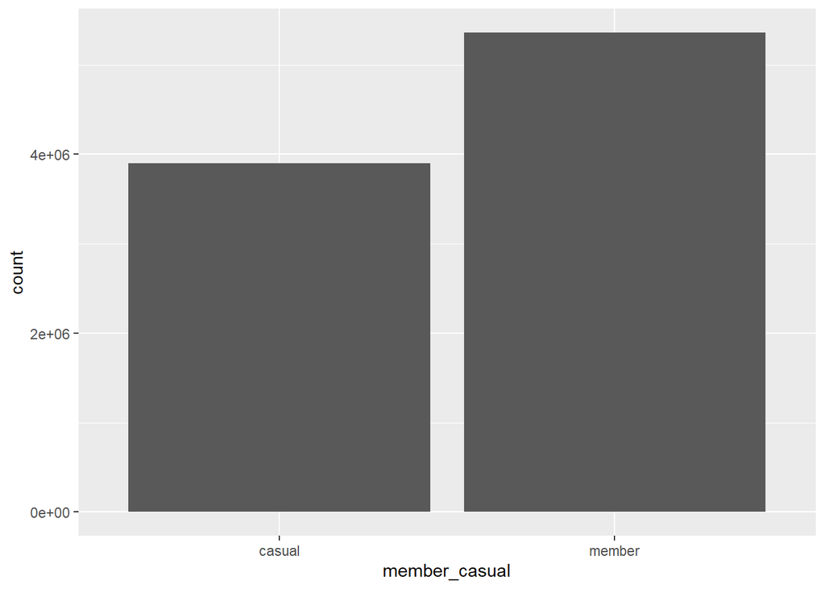

```r
ggplot(df, aes(x=member_casual)) +
  geom_bar()
```

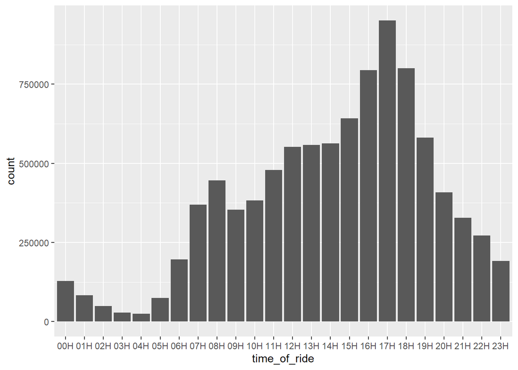

```r
ggplot(df, aes(x=time_of_ride)) +
  geom_bar()
```

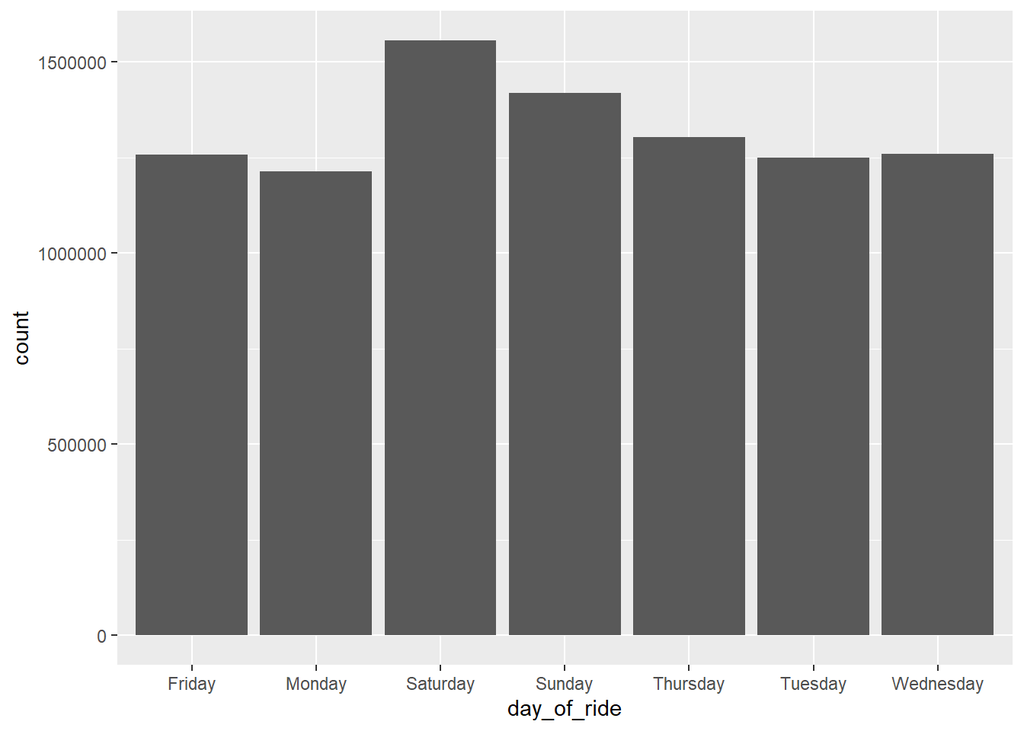

```r
ggplot(df, aes(x=day_of_ride)) +
  geom_bar()
```

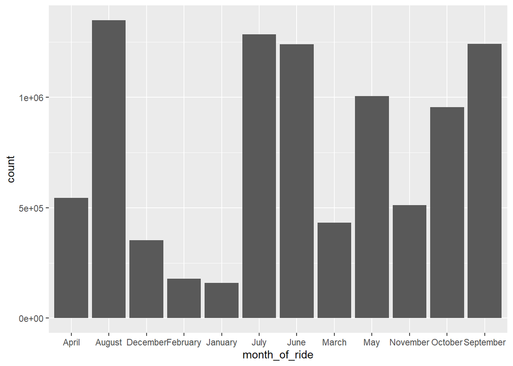

```r
ggplot(df, aes(x=month_of_ride)) +
  geom_bar()
```

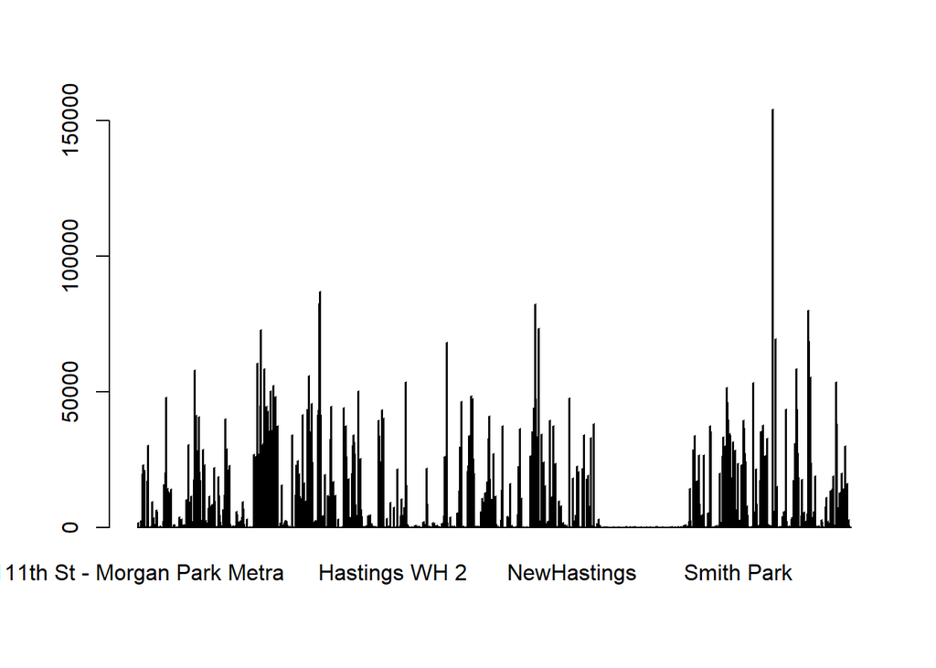

```r
barplot(table(df$start_station_name))
```

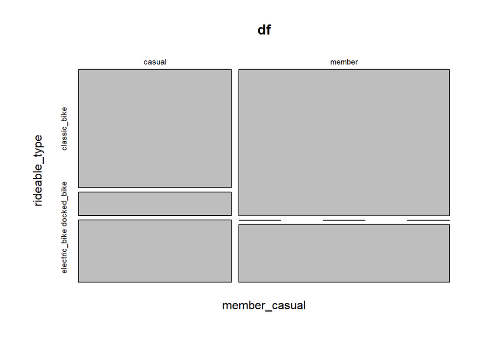

```r
mosaicplot(member_casual~rideable_type,data=df)
```

### Using Power BI for effective visualization and to answer business question

### Exporting data in text format, Power BI have an option to open text format data

### using below command

write.table(df, file=‘all_data_bike_share.txt’, sep = “;”)